# Statistical Learning Final Project

## Team Members

**Andrew Piasecki**  
Email

*That’s it*

# Introduction

In the field of data science, machine learning is a powerful tool for making predictions and identifying patterns in data. In this context, principal component analysis (PCA), cross-validation (CV), and support vector machines (SVM) are commonly used methods for analyzing and modeling data. In this project, we will apply these techniques to a breast cancer dataset, which contains information about various features of breast tumors and their diagnosis as malignant or benign.

In addition to implementing these methods, we will also visualize the data to gain insights and explore relationships between different features. Furthermore, we will run tests to evaluate the performance of our models and compare them with each other. All of this will be done using R. Overall, this project will provide a hands-on opportunity to gain practical experience with these important machine learning techniques in the context of a real-world dataset.

# Install and Import Packages

```r
# Load the required packages
install.packages("readxl")
```

```
Error in install.packages : Updating loaded packages
```

```r
install.packages("factoextra")
```

```
Error in install.packages : Updating loaded packages
```

```r
install.packages("FactoMineR")
```

```
Error in install.packages : Updating loaded packages
```

```r
install.packages("kernlab")
```

```
Error in install.packages : Updating loaded packages
```

```r
library(readxl)
library(stats)
library(tidyverse)
library(caret)
library(kernlab)
library(FactoMineR)
library(factoextra)
library(e1071)
library(ggplot2)
```

# PCA

## Reading and Preparing Data

```r
# Read data from a CSV file hosted on GitHub
bc <- read.csv("https://raw.githubusercontent.com/AndrewPiasecki/Breast_Cancer/main/data.csv")

# Remove non-numeric columns from the data
data <- bc[,3:32]

# Standardize the numeric columns in the data
data_scaled <- scale(data)
```

## Perform PCA

```r
# Perform PCA on the standardized data
pca <- prcomp(data_scaled, center = TRUE, scale. = TRUE)

# Extract the principal components
PC1 <- pca$x[, 1]
PC2 <- pca$x[, 2]
PC3 <- pca$x[, 3]
PC4 <- pca$x[, 4]
PC5 <- pca$x[, 5]
PC6 <- pca$x[, 6]

# Print a summary of the principal component analysis
summary(pca)
```

```
Importance of components:
                          PC1    PC2     PC3     PC4     PC5     PC6     PC7     PC8    PC9    PC10   PC11    PC12    PC13    PC14    PC15    PC16    PC17    PC18    PC19
Standard deviation     3.6444 2.3857 1.67867 1.40735 1.28403 1.09880 0.82172 0.69037 0.6457 0.59219 0.5421 0.51104 0.49128 0.39624 0.30681 0.28260 0.24372 0.22939 0.22244
Proportion of Variance 0.4427 0.1897 0.09393 0.06602 0.05496 0.04025 0.02251 0.01589 0.0139 0.01169 0.0098 0.00871 0.00805 0.00523 0.00314 0.00266 0.00198 0.00175 0.00165
Cumulative Proportion  0.4427 0.6324 0.72636 0.79239 0.84734 0.88759 0.91010 0.92598 0.9399 0.95157 0.9614 0.97007 0.97812 0.98335 0.98649 0.98915 0.99113 0.99288 0.99453
                          PC20   PC21    PC22    PC23   PC24    PC25    PC26    PC27    PC28    PC29    PC30
Standard deviation     0.17652 0.1731 0.16565 0.15602 0.1344 0.12442 0.09043 0.08307 0.03987 0.02736 0.01153
Proportion of Variance 0.00104 0.0010 0.00091 0.00081 0.0006 0.00052 0.00027 0.00023 0.00005 0.00002 0.00000
Cumulative Proportion  0.99557 0.9966 0.99749 0.99830 0.9989 0.99942 0.99969 0.99992 0.99997 1.00000 1.00000
```

## Visualizing Principal Components

List of Scatter Plots

- PC1 vs PC2
- PC2 vs PC3
- PC3 vs PC4
- PC4 vs PC5
- PC5 vs PC6
- PC1 vs PC6

### PC1 vs PC2

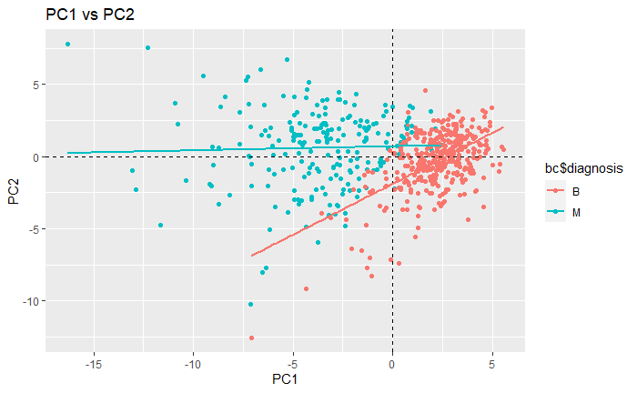

### PC2 vs PC3

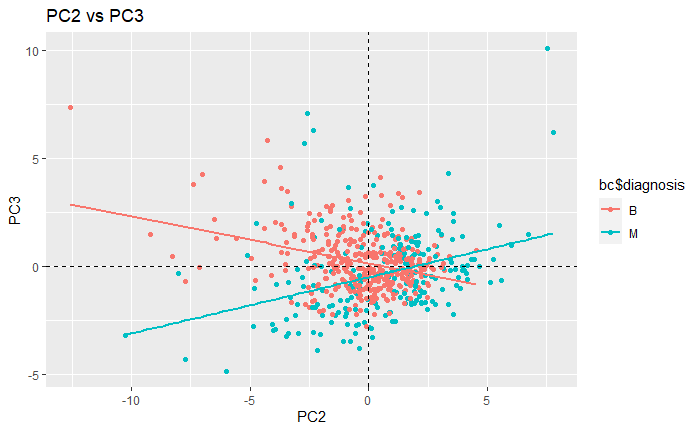

```r
scatter_plotP23 <- ggplot(data, aes(x = PC2, y = PC3, color = bc$diagnosis)) +
  geom_point() +
  geom_vline(xintercept = 0, linetype = "dashed") +
  geom_hline(yintercept = 0, linetype = "dashed") +
  geom_smooth(method = "lm", se = FALSE) +
  labs(title = "PC2 vs PC3", x = "PC2", y = "PC3")
scatter_plotP23
```

### PC3 vs PC4

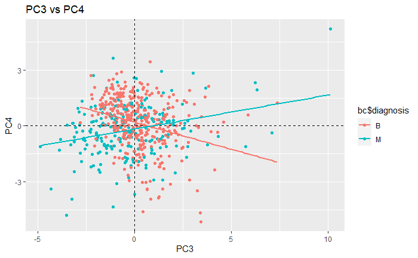

```r
scatter_plotP34 <- ggplot(data, aes(x = PC3, y = PC4, color = bc$diagnosis)) +
  geom_point() +
  geom_vline(xintercept = 0, linetype = "dashed") +
  geom_hline(yintercept = 0, linetype = "dashed") +
  geom_smooth(method = "lm", se = FALSE) +
  labs(title = "PC3 vs PC4", x = "PC3", y = "PC4")
scatter_plotP34
```

### PC4 vs PC5

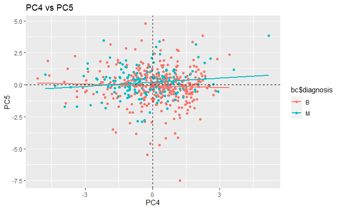

```r
scatter_plotP45 <- ggplot(data, aes(x = PC4, y = PC5, color = bc$diagnosis)) +
  geom_point() +
  geom_vline(xintercept = 0, linetype = "dashed") +
  geom_hline(yintercept = 0, linetype = "dashed") +
  geom_smooth(method = "lm", se = FALSE) +
  labs(title = "PC4 vs PC5", x = "PC4", y = "PC5")
scatter_plotP45
```

### PC5 vs PC6

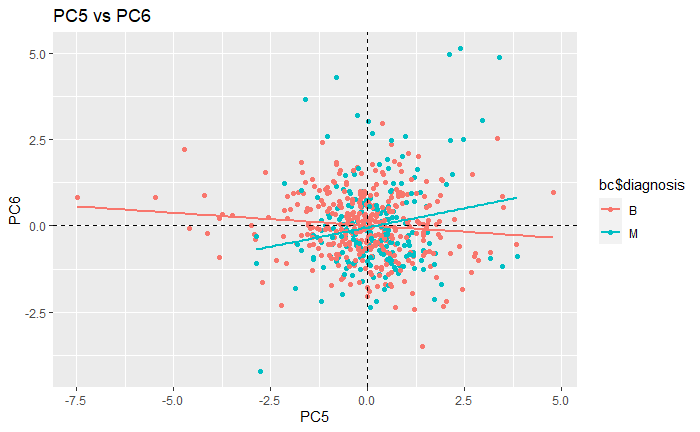

```r
scatter_plotP56 <- ggplot(data, aes(x = PC5, y = PC6, color = bc$diagnosis)) +
  geom_point() +
  geom_vline(xintercept = 0, linetype = "dashed") +
  geom_hline(yintercept = 0, linetype = "dashed") +
  geom_smooth(method = "lm", se = FALSE) +
  labs(title = "PC5 vs PC6", x = "PC5", y = "PC6")
scatter_plotP56
```

### PC1 vs PC6

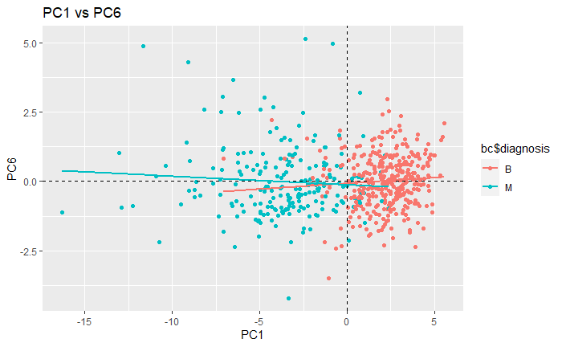

## Eigen Values and Scree Plot

```r
# Create a table showing the different eigenvalue, variance.percentm and cumulative.variance.percent of different dimensions
get_eigenvalue(pca)
```

|  | eigenvalue | variance.percent | cumulative.variance.percent |
| --- | --- | --- | --- |
| Dim.1 | 1.328161e+01 | 4.427203e+01 | 44.27203 |
| Dim.2 | 5.691355e+00 | 1.897118e+01 | 63.24321 |
| Dim.3 | 2.817949e+00 | 9.393163e+00 | 72.63637 |
| Dim.4 | 1.980640e+00 | 6.602135e+00 | 79.23851 |
| Dim.5 | 1.648731e+00 | 5.495768e+00 | 84.73427 |
| Dim.6 | 1.207357e+00 | 4.024522e+00 | 88.75880 |
| Dim.7 | 6.752201e-01 | 2.250734e+00 | 91.00953 |
| Dim.8 | 4.766171e-01 | 1.588724e+00 | 92.59825 |
| Dim.9 | 4.168948e-01 | 1.389649e+00 | 93.98790 |
| Dim.10 | 3.506935e-01 | 1.168978e+00 | 95.15688 |

[output cut: 20 more lines]

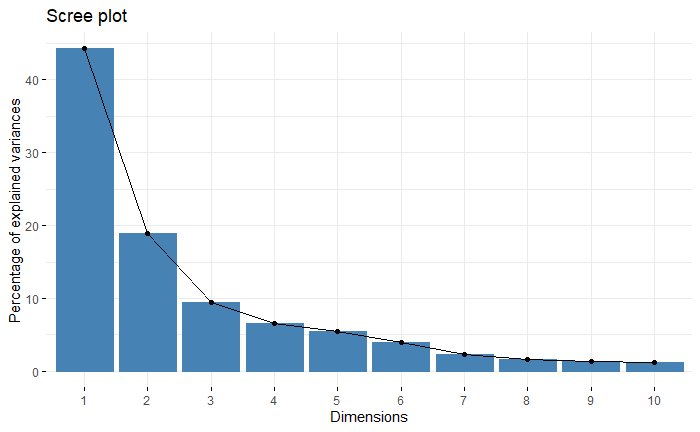

```r
# Plot a Scree Plot showing different variances at different PCA values
fviz_eig(pca)
```

```r
svmPCA <- svm(PC2 ~ PC1, data = bc, kernel = "linear", cost = 10, scale = FALSE)
summary(svmPCA)
```

```
Call:
svm(formula = PC2 ~ PC1, data = bc, kernel = "linear", cost = 10, scale = FALSE)


Parameters:
   SVM-Type:  eps-regression
 SVM-Kernel:  linear
       cost:  10
      gamma:  1
    epsilon:  0.1


Number of Support Vectors:  545
```

```r
plot(svmPCA)
```

[output not shown]

# Cross-Validation (CV)

## Split the data into training and test set

```r
set.seed(123)
training.samples <- data$radius_mean %>%
  createDataPartition(p = 0.8, list = FALSE)
train.data  <- data[training.samples, ]
test.data <- data[-training.samples, ]
```

## Build The Model

```r
model <- lm(radius_mean ~ texture_mean, data)
```

## Make predictions and compute the R2, RMSE and MAE

```r
predictions <- model %>% predict(data)
data.frame( R2 = R2(predictions, data$radius_mean),
            RMSE = RMSE(predictions, data$radius_mean),
            MAE = MAE(predictions, data$radius_mean))
```

| R2 | RMSE | MAE |
| --- | --- | --- |
| 0.1048347 | 3.331283 | 2.58418 |

When comparing two models, the one that produces the lowest test sample RMSE is the preferred model.

the RMSE and the MAE are measured in the same scale as the outcome variable. Dividing the RMSE by the average value of the outcome variable will give you the prediction error rate, which should be as small as possible:

```r
RMSE(predictions, data$radius_mean)/mean(data$radius_mean)
```

```
[1] 0.2358048
```

- I can then **plot** the model and it shows four different graphs
1. Residuals vs Fitted (This plot shows the relationship between the residuals (the difference between the observed values and the predicted values) and the fitted values (the predicted values).)
2. Normal Q-Q (This plot compares the distribution of the residuals to a normal distribution. If the residuals are normally distributed, then the points on the plot will fall along a straight line. However, if there are deviations from the straight line, this may indicate that the residuals are not normally distributed, which could affect the validity of the model.)
3. Scale-Location (The purpose of this plot is to check for heteroscedasticity, which is a violation of the assumption that the variance of the residuals is constant across all levels of the independent variables. )
4. Residuals vs Leverage (This plot shows the leverage (a measure of how much a data point influences the regression line) plotted against the residuals. The purpose of this plot is to identify outliers or influential observations.)
- **Heteroscedasticity** happens when the standard deviations of a predicted variable, monitored over different values of an independent variable or as related to prior time periods, are non-constant.

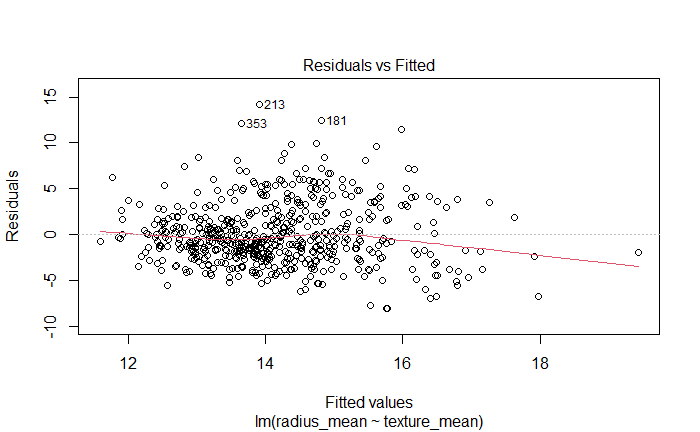

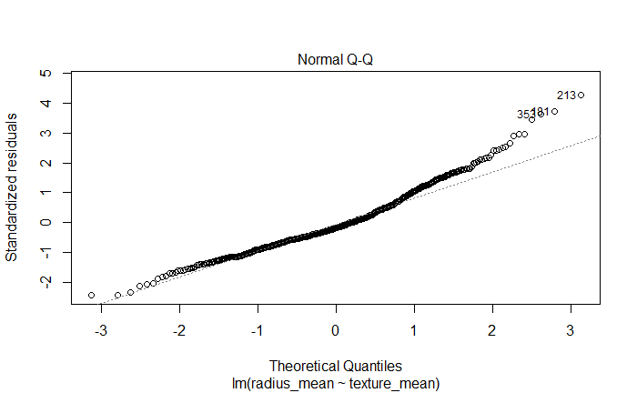

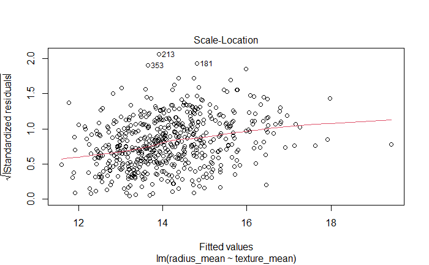

```r
plot(model)
```

[figure not shown]

```r
install.packages("kernlab")
```

## LOOCV

### Define training control

```r
LOOtrain.control <- trainControl(method = "LOOCV")
```

### Train the model

```r
LOOmodel <- train(radius_mean ~ texture_mean, data, method = "lm",
               trControl = LOOtrain.control)
```

### Summarize the results

```r
print(LOOmodel)
```

```
Linear Regression

569 samples
  1 predictor

No pre-processing
Resampling: Leave-One-Out Cross-Validation
Summary of sample sizes: 568, 568, 568, 568, 568, 568, ...
Resampling results:

  RMSE      Rsquared    MAE
  3.343553  0.09834935  2.593658

Tuning parameter 'intercept' was held constant at a value of TRUE
```

The advantage of the *LOOCV method* is that we make use all data points reducing potential bias.

However, the process is repeated as many times as there are data points, resulting to a higher execution time when n is extremely large.

Additionally, we test the model performance against one data point at each iteration. This might result to higher variation in the prediction error, if some data points are outliers.  
This leads to K-fold Cross Validation

## K-fold Cross Validation

### Define training control

```r
set.seed(123)
KFtrain.control <- trainControl(method = "cv", number = 10)
```

### Train the model

```r
KFmodel <- train(radius_mean ~ texture_mean, data, method = "lm",
               trControl = KFtrain.control)
```

### Summarize the results

```r
print(KFmodel)
```

```
Linear Regression

569 samples
  1 predictor

No pre-processing
Resampling: Cross-Validated (10 fold)
Summary of sample sizes: 512, 513, 511, 512, 513, 513, ...
Resampling results:

  RMSE      Rsquared   MAE
  3.331906  0.1197295  2.590872

Tuning parameter 'intercept' was held constant at a value of TRUE
```

# Module PCA txt

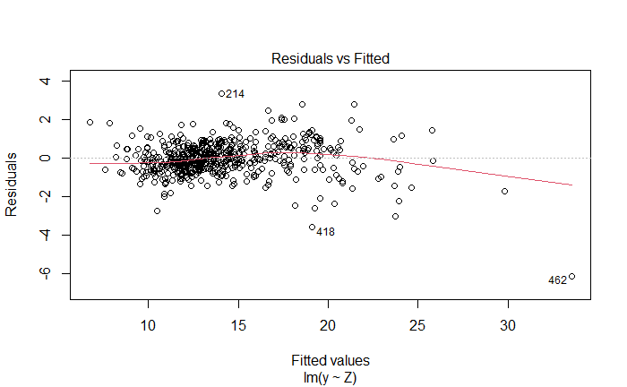

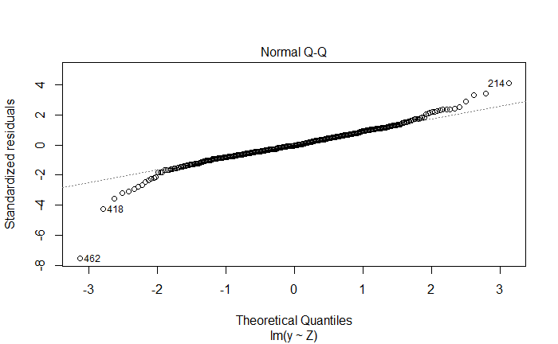

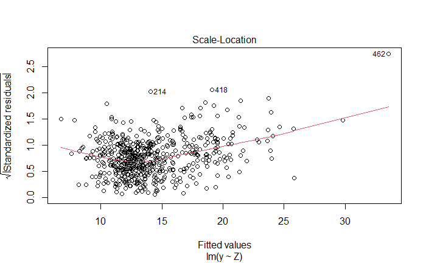

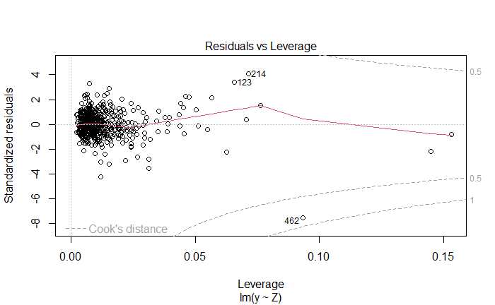

```r
X <- as.matrix(data[, -1]) # remove the first column (car names) and

y <- data[, 1] # extract the first column (mpg)
pca <- prcomp(X, scale = TRUE)
prop.var <- pca$sdev^2 / sum(pca$sdev^2)
cum.prop.var <- cumsum(prop.var)
num.components <- sum(cum.prop.var < 0.9) # choose the number of


Z <- pca$x[, 1:num.components]
model <- lm(y ~ Z)
plot(model)
```

```r
summary(model)
```

```
Call:
lm(formula = y ~ Z)

Residuals:
    Min      1Q  Median      3Q     Max
-6.1243 -0.4677 -0.0404  0.5026  3.3637

Coefficients:
            Estimate Std. Error t value Pr(>|t|)
(Intercept) 14.12729    0.03582 394.347  < 2e-16 ***
ZPC1         0.75139    0.01007  74.607  < 2e-16 ***
ZPC2        -0.91059    0.01549 -58.779  < 2e-16 ***
ZPC3        -0.03511    0.02136  -1.644   0.1008
ZPC4         0.16286    0.02550   6.386 3.57e-10 ***
ZPC5        -0.14864    0.02795  -5.318 1.51e-07 ***
ZPC6         0.07118    0.03264   2.181   0.0296 *
---
Signif. codes:  0 ‘***’ 0.001 ‘**’ 0.01 ‘*’ 0.05 ‘.’ 0.1 ‘ ’ 1

Residual standard error: 0.8545 on 562 degrees of freedom
Multiple R-squared:  0.9418,    Adjusted R-squared:  0.9412
F-statistic:  1516 on 6 and 562 DF,  p-value: < 2.2e-16
```

```r
X_new <- X[1:5, ] # use the first 5 rows of the data as new predictors


Z_new <- predict(pca, newdata = X_new)[, 1:num.components] # project the

summary(Z_new)
```

```
      PC1             PC2               PC3               PC4              PC5               PC6
 Min.   :1.890   Min.   :-3.6088   Min.   :-3.2112   Min.   :0.1304   Min.   :-0.6301   Min.   :-1.22680
 1st Qu.:3.559   1st Qu.:-1.9001   1st Qu.:-1.1256   1st Qu.:0.9244   1st Qu.:-0.5682   1st Qu.: 0.02747
 Median :5.470   Median :-1.2297   Median :-0.5552   Median :1.1164   Median : 0.1621   Median : 0.54290
 Mean   :5.600   Mean   : 0.8739   Mean   :-0.8070   Mean   :1.7556   Mean   : 0.6172   Mean   : 0.76246
 3rd Qu.:7.853   3rd Qu.: 1.4248   3rd Qu.:-0.5327   3rd Qu.:2.9295   3rd Qu.: 1.1267   3rd Qu.: 1.43375
 Max.   :9.227   Max.   : 9.6835   Max.   : 1.3897   Max.   :3.6774   Max.   : 2.9954   Max.   : 3.03497
```

# Conclusion

In this project, we performed principal component analysis (PCA) on a dataset of [breast cancer](https://raw.githubusercontent.com/AndrewPiasecki/Breast_Cancer/main/data.csv). After standardizing the data, we performed PCA and extracted the first six principal components. We then visualized the first six principal components using scatter plots. In addition, we created a scree plot to visualize the eigenvalues of the principal components.